# ECON320 Lab Final Project Jerry

Jerry Zhao

06 December, 2018

```r
knitr::opts_chunk$set(echo = TRUE)
knitr::opts_chunk$set(tidy.opts = list(width.cutoff=50),tidy=TRUE)
library(tidyverse) #call Tidyverse Package for future use
```

```r
library(ggplot2) #call ggplot2 Package for future use
library(dplyr) #call dplyr package for future use
library(readxl) #call readxl package for excel import
library(stargazer)
library(reshape2) #call reshape2 package for melting dataframe
AAPLSTOCK <- read_excel(file.choose()) #read data from local path
```

### Research Goal

This research use the daily Apple and its supplers’ stock prices of the last 10 years starting from 2008 (Where Apple stock starts to skyrocket)

| Suppliers | Description |
| --- | --- |
| MU | Major RAM supplier |
| JBL | Major Phone Casings |
| ADI | Touch screen controllers Provider |
| GLUU | Major provider of iOS apps and mobile games |
| QCOM | Supply Majority electronic components |
| STM | Three-axis gyroscope and accelerometer |
| TXN | Chip and control device |

*Data sourced from FactSet, a reliable financial database*

### Summary of Data

```r
AAPLSTOCK <- as.data.frame(AAPLSTOCK) #make sure trhe dataset is recognized as dataframe for stargazer to recognize
summary(AAPLSTOCK) #summarize data
```

```
  Date                          AAPL              MU
```

Min. :2008-10-22 00:00:00 Min. : 11.17 Min. : 1.690  
1st Qu.:2011-05-03 12:00:00 1st Qu.: 49.52 1st Qu.: 7.593  
Median :2013-11-12 00:00:00 Median : 83.68 Median :12.530  
Mean :2013-11-12 17:06:42 Mean : 89.58 Mean :18.394  
3rd Qu.:2016-05-24 12:00:00 3rd Qu.:117.58 3rd Qu.:27.790  
Max. :2018-12-03 00:00:00 Max. :232.07 Max. :62.620  
ADI GLUU JBL QCOM  
Min. : 16.10 Min. :0.230 Min. : 3.16 Min. :29.21  
1st Qu.: 35.97 1st Qu.:2.170 1st Qu.:17.50 1st Qu.:50.21  
Median : 48.38 Median :3.105 Median :20.24 Median :57.43  
Mean : 51.37 Mean :3.240 Mean :20.00 Mean :57.50  
3rd Qu.: 62.69 3rd Qu.:4.290 3rd Qu.:23.40 3rd Qu.:66.11  
Max. :102.10 Max. :8.210 Max. :31.46 Max. :81.60  
STM TXN  
Min. : 3.790 Min. : 13.77  
1st Qu.: 7.045 1st Qu.: 28.72  
Median : 8.270 Median : 41.93  
Mean :10.014 Mean : 49.15  
3rd Qu.:10.210 3rd Qu.: 60.02  
Max. :26.240 Max. :119.89

```r
str(AAPLSTOCK) #Str Data
```

‘data.frame’: 2547 obs. of 9 variables: $ Date: POSIXct, format: “2018-12-03” “2018-11-30” … $ AAPL: num 185 179 180 181 174 … $ MU : num 40 38.6 37.9 38.7 37 … $ ADI : num 93.5 91.9 89.5 90.7 89.1 … $ GLUU: num 7.6 7.35 7.14 6.93 6.8 6.85 6.85 6.92 6.69 7.78 … $ JBL : num 25.5 25.1 25.2 24.8 24.6 … $ QCOM: num 59.1 58.3 58.1 56.7 55.6 … $ STM : num 15.6 14.8 14.8 14.7 14.3 … $ TXN : num 101.2 99.8 97.4 98.3 96.3 …

```r
stargazer(AAPLSTOCK, type="html") #Stargazer summary
```

| Statistic | N | Mean | St. Dev. | Min | Pctl(25) | Pctl(75) | Max |
| --- | --- | --- | --- | --- | --- | --- | --- |
| AAPL | 2,547 | 89.578 | 50.729 | 11.171 | 49.516 | 117.575 | 232.070 |
| MU | 2,547 | 18.394 | 13.894 | 1.690 | 7.592 | 27.790 | 62.620 |
| ADI | 2,547 | 51.371 | 21.143 | 16.100 | 35.970 | 62.685 | 102.100 |
| GLUU | 2,547 | 3.240 | 1.672 | 0.230 | 2.170 | 4.290 | 8.210 |
| JBL | 2,547 | 19.999 | 5.855 | 3.160 | 17.500 | 23.400 | 31.460 |
| QCOM | 2,547 | 57.496 | 11.574 | 29.210 | 50.210 | 66.115 | 81.600 |
| STM | 2,547 | 10.014 | 4.948 | 3.790 | 7.045 | 10.210 | 26.240 |
| TXN | 2,547 | 49.146 | 26.568 | 13.770 | 28.723 | 60.015 | 119.890 |

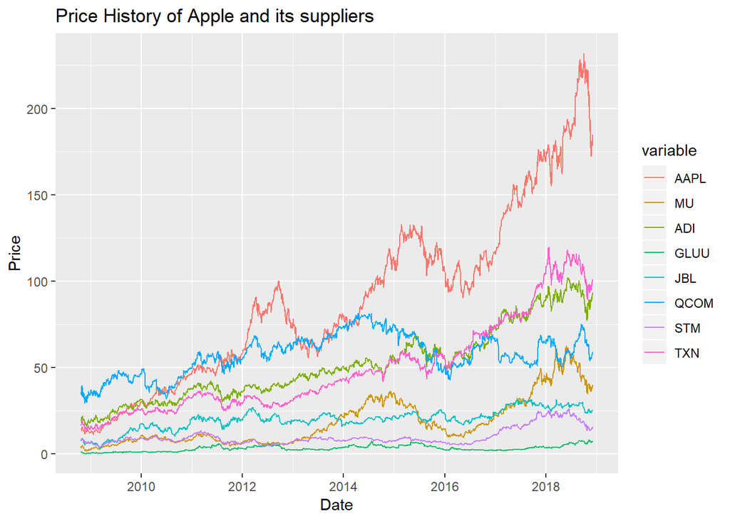

```r
mdf1 <- melt(AAPLSTOCK, id.vars='Date') ##Melt dataframe from a "short and wide format into a long and thin format ( more rows )"
ggplot(mdf1, aes(x=Date, y=value, col=variable)) + geom_line()+
  labs(title="Price History of Apple and its suppliers", y="Price", x="Date")#Plot all supplier stocks with Apple stock
```

### Simple Regression and Descriptive Stats of Each Variable

**Regression btw AAPL and MU**

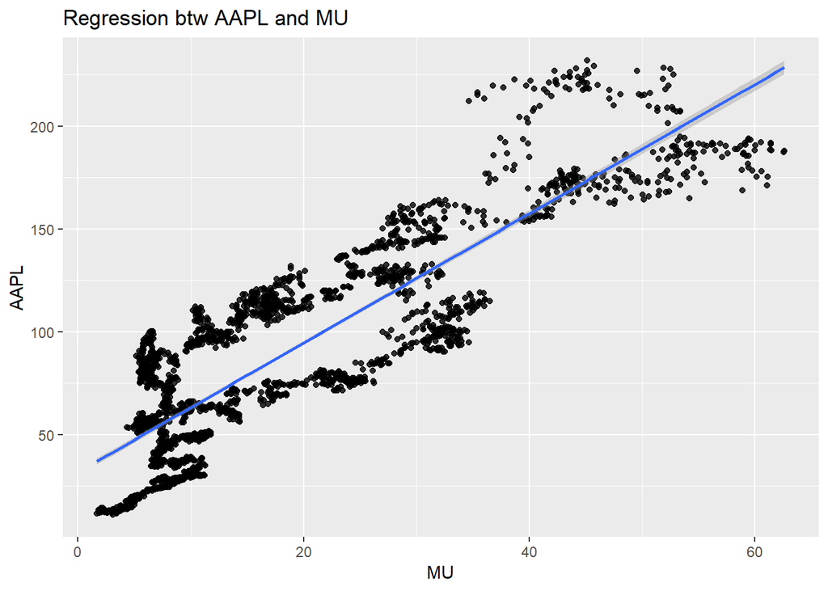

```r
ggplot(data=AAPLSTOCK, mapping=aes(x=MU,y=AAPL)) +
  geom_point(alpha=0.8)+
  geom_smooth(method='lm')+
  labs(title="Regression btw AAPL and MU", y="AAPL", x="MU")#Regression btw AAPL and MU
```

```r
model1 <- lm(formula=AAPL ~ MU, data = AAPLSTOCK) #Regression of AAPL and MU
summary(model1) #Get the summary of the regression (R^2, p value)
```

```
##
## Call:
## lm(formula = AAPL ~ MU, data = AAPLSTOCK)
##
## Residuals:
##    Min     1Q Median     3Q    Max
## -52.43 -25.13  -2.36  25.23  73.28
##
## Coefficients:
##             Estimate Std. Error t value Pr(>|t|)
## (Intercept) 31.77044    0.84919   37.41   <2e-16 ***
## MU           3.14278    0.03684   85.31   <2e-16 ***
## ---
## Signif. codes:  0 '***' 0.001 '**' 0.01 '*' 0.05 '.' 0.1 ' ' 1
##
## Residual standard error: 25.83 on 2545 degrees of freedom
## Multiple R-squared:  0.7409, Adjusted R-squared:  0.7408
## F-statistic:  7277 on 1 and 2545 DF,  p-value: < 2.2e-16
```

**Regression btw AAPL and ADI**

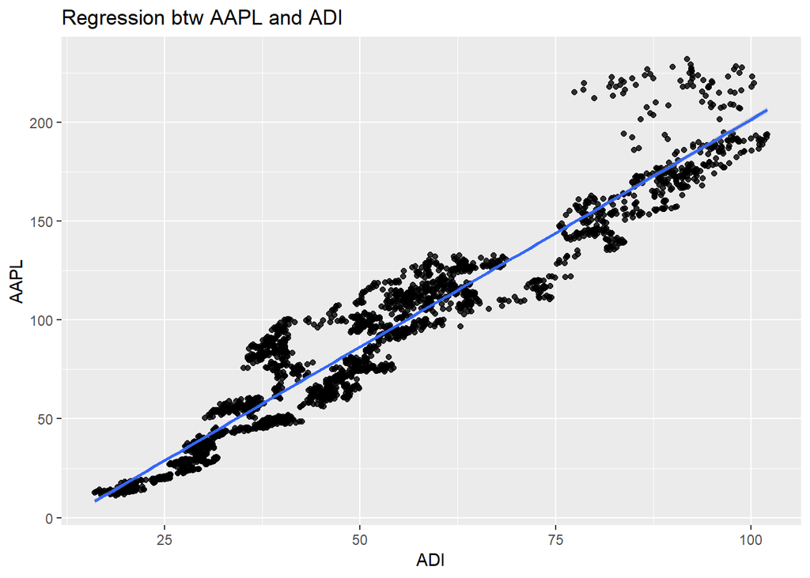

```r
ggplot(data=AAPLSTOCK, mapping=aes(x=ADI,y=AAPL)) +
  geom_point(alpha=0.8)+
  geom_smooth(method='lm')+
  labs(title="Regression btw AAPL and ADI", y="AAPL", x="ADI")#Regression btw AAPL and ADI
```

```r
model2 <- lm(formula=AAPL ~ ADI, data = AAPLSTOCK)
summary(model2)
```

```
##
## Call:
## lm(formula = AAPL ~ ADI, data = AAPLSTOCK)
##
## Residuals:
##     Min      1Q  Median      3Q     Max
## -31.678 -10.137  -3.242   7.830  67.440
##
## Coefficients:
##              Estimate Std. Error t value Pr(>|t|)
## (Intercept) -28.62475    0.74873  -38.23   <2e-16 ***
## ADI           2.30096    0.01348  170.71   <2e-16 ***
## ---
## Signif. codes:  0 '***' 0.001 '**' 0.01 '*' 0.05 '.' 0.1 ' ' 1
##
## Residual standard error: 14.38 on 2545 degrees of freedom
## Multiple R-squared:  0.9197, Adjusted R-squared:  0.9197
## F-statistic: 2.914e+04 on 1 and 2545 DF,  p-value: < 2.2e-16
```

**Regression btw AAPL and GLUU**

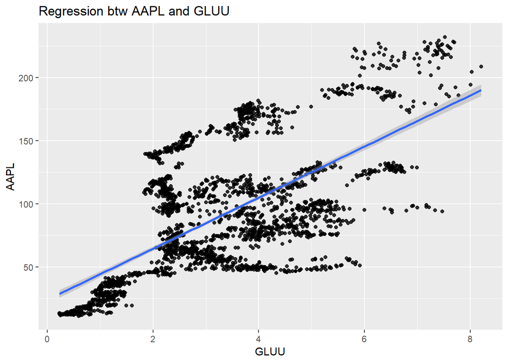

```r
ggplot(data=AAPLSTOCK, mapping=aes(x=GLUU,y=AAPL)) +
  geom_point(alpha=0.8)+
  geom_smooth(method='lm')+
  labs(title="Regression btw AAPL and GLUU", y="AAPL", x="GLUU")#Regression btw AAPL and GLUU
```

```r
model3 <- lm(formula=AAPL ~ GLUU, data = AAPLSTOCK)
summary(model3)
```

```
##
## Call:
## lm(formula = AAPL ~ GLUU, data = AAPLSTOCK)
##
## Residuals:
##    Min     1Q Median     3Q    Max
## -92.42 -24.59 -12.83  27.14  81.22
##
## Coefficients:
##             Estimate Std. Error t value Pr(>|t|)
## (Intercept)  24.1025     1.6354   14.74   <2e-16 ***
## GLUU         20.2070     0.4485   45.05   <2e-16 ***
## ---
## Signif. codes:  0 '***' 0.001 '**' 0.01 '*' 0.05 '.' 0.1 ' ' 1
##
## Residual standard error: 37.84 on 2545 degrees of freedom
## Multiple R-squared:  0.4437, Adjusted R-squared:  0.4435
## F-statistic:  2030 on 1 and 2545 DF,  p-value: < 2.2e-16
```

**Regression btw AAPL and JBL**

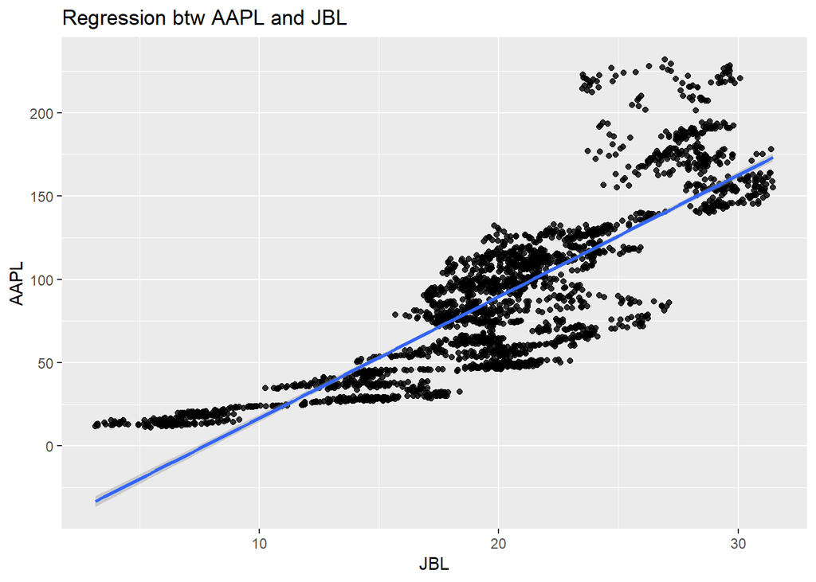

```r
ggplot(data=AAPLSTOCK, mapping=aes(x=JBL,y=AAPL)) +
  geom_point(alpha=0.8)+
  geom_smooth(method='lm')+
labs(title="Regression btw AAPL and JBL", y="AAPL", x="JBL") #Regression btw AAPL and JBL
```

```r
model4 <- lm(formula=AAPL ~ JBL, data = AAPLSTOCK)
summary(model4)
```

```
##
## Call:
## lm(formula = AAPL ~ JBL, data = AAPLSTOCK)
##
## Residuals:
##     Min      1Q  Median      3Q     Max
## -61.837 -17.322   1.209  17.162 107.397
##
## Coefficients:
##              Estimate Std. Error t value Pr(>|t|)
## (Intercept) -56.29801    1.93133  -29.15   <2e-16 ***
## JBL           7.29414    0.09268   78.70   <2e-16 ***
## ---
## Signif. codes:  0 '***' 0.001 '**' 0.01 '*' 0.05 '.' 0.1 ' ' 1
##
## Residual standard error: 27.38 on 2545 degrees of freedom
## Multiple R-squared:  0.7088, Adjusted R-squared:  0.7087
## F-statistic:  6194 on 1 and 2545 DF,  p-value: < 2.2e-16
```

**Regression btw AAPL and QCOM**

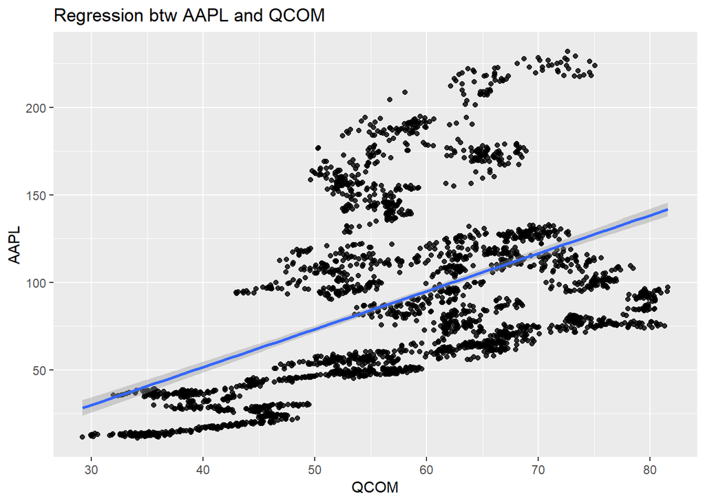

```r
ggplot(data=AAPLSTOCK, mapping=aes(x=QCOM,y=AAPL)) +
  geom_point(alpha=0.8)+
  geom_smooth(method='lm')+
  labs(title="Regression btw AAPL and QCOM", y="AAPL", x="QCOM") #Regression btw AAPL and QCOM
```

```r
model5 <- lm(formula=AAPL ~ QCOM, data = AAPLSTOCK)
summary(model5)
```

```
##
## Call:
## lm(formula = AAPL ~ QCOM, data = AAPLSTOCK)
##
## Residuals:
##    Min     1Q Median     3Q    Max
## -66.20 -33.87 -16.80  21.99 119.18
##
## Coefficients:
##              Estimate Std. Error t value Pr(>|t|)
## (Intercept) -34.98766    4.42965  -7.899 4.16e-15 ***
## QCOM          2.16652    0.07553  28.685  < 2e-16 ***
## ---
## Signif. codes:  0 '***' 0.001 '**' 0.01 '*' 0.05 '.' 0.1 ' ' 1
##
## Residual standard error: 44.11 on 2545 degrees of freedom
## Multiple R-squared:  0.2443, Adjusted R-squared:  0.244
## F-statistic: 822.8 on 1 and 2545 DF,  p-value: < 2.2e-16
```

**Regression btw AAPL and STM**

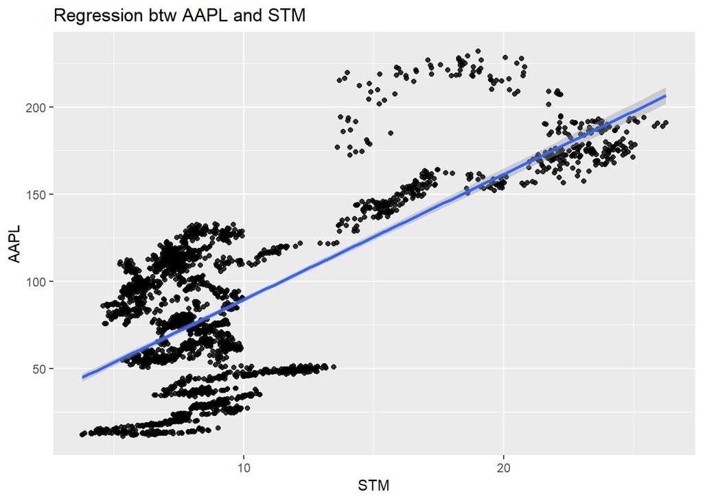

```r
ggplot(data=AAPLSTOCK, mapping=aes(x=STM,y=AAPL)) +
  geom_point(alpha=0.8)+
  geom_smooth(method='lm')+
  labs(title="Regression btw AAPL and STM", y="AAPL", x="STM") #Regression btw AAPL and STM
```

```r
model6 <- lm(formula=AAPL ~ STM, data = AAPLSTOCK)
summary(model6)
```

```
##
## Call:
## lm(formula = AAPL ~ STM, data = AAPLSTOCK)
##
## Residuals:
##     Min      1Q  Median      3Q     Max
## -66.565 -33.316  -0.359  32.302 101.591
##
## Coefficients:
##             Estimate Std. Error t value Pr(>|t|)
## (Intercept)  17.4693     1.6159   10.81   <2e-16 ***
## STM           7.2008     0.1447   49.77   <2e-16 ***
## ---
## Signif. codes:  0 '***' 0.001 '**' 0.01 '*' 0.05 '.' 0.1 ' ' 1
##
## Residual standard error: 36.12 on 2545 degrees of freedom
## Multiple R-squared:  0.4932, Adjusted R-squared:  0.493
## F-statistic:  2477 on 1 and 2545 DF,  p-value: < 2.2e-16
```

**Regression btw AAPL and TXN**

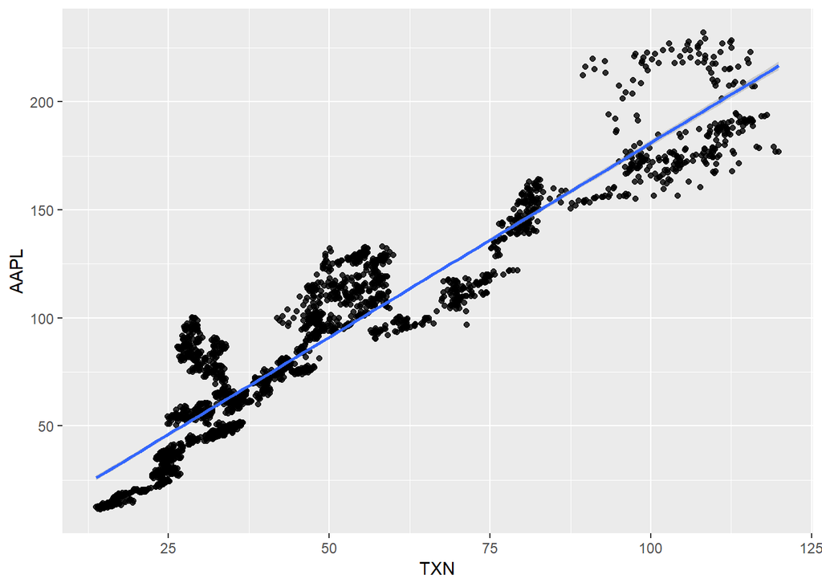

```r
ggplot(data=AAPLSTOCK, mapping=aes(x=TXN,y=AAPL)) +
  geom_point(alpha=0.8)+
  geom_smooth(method='lm') #Regression btw AAPL and TXN
```

```r
model7 <- lm(formula=AAPL ~ TXN, data = AAPLSTOCK)
summary(model7)
```

```
##
## Call:
## lm(formula = AAPL ~ TXN, data = AAPLSTOCK)
##
## Residuals:
##     Min      1Q  Median      3Q     Max
## -39.780 -14.375  -3.121  11.224  54.966
##
## Coefficients:
##             Estimate Std. Error t value Pr(>|t|)
## (Intercept)  1.18381    0.70980   1.668   0.0955 .
## TXN          1.79862    0.01271 141.560   <2e-16 ***
## ---
## Signif. codes:  0 '***' 0.001 '**' 0.01 '*' 0.05 '.' 0.1 ' ' 1
##
## Residual standard error: 17.03 on 2545 degrees of freedom
## Multiple R-squared:  0.8873, Adjusted R-squared:  0.8873
## F-statistic: 2.004e+04 on 1 and 2545 DF,  p-value: < 2.2e-16
```

From all the simple regression analysis above, we can conclude that AAPL is most correlated with TXN, ADI (High R square value and small residual standard error/ least correlated with QCOM, GLUU, and STM.

### Multiple Regression to Determine the Optimum Group of Stocks

To find the best group of suppliers stocks that explain Apple stock price well, I need to start by incorporate every variables as they are all supplier of Apple:

$$AAPL = \beta_0 + \beta_1MU + \beta_2ADI + \beta_3GLUU + \beta_4JBL + \beta_5QCOM + \beta_6STM + \beta_7TXN$$

Then from the simple regression before, I find Apple stock is not very correlated with QCOM, GLUU, and STM, so I will pick them out:

$$AAPL = \beta_0 + \beta_1MU + \beta_2ADI + \beta_3JBL + \beta_4TXN$$

Then I will also run apple stock with only the two most correlated suppliers, TXN and ADI:

$$AAPL = \beta_0 + \beta_1ADI + \beta_2TXN$$

```r
AAPL.1 <- lm(AAPL ~ MU + ADI + GLUU + JBL + QCOM + STM + TXN, data=AAPLSTOCK) #Run a regression of all suppliers' stock
AAPL.2 <- lm(AAPL ~ MU + ADI + JBL + TXN, data=AAPLSTOCK) #Run a Regression excluding less correlated stocks
AAPL.3 <- lm(AAPL ~ ADI + TXN, data=AAPLSTOCK)#Run a regression with only most correlated stocks
stargazer(list(AAPL.1, AAPL.2, AAPL.3), type="html", align=TRUE, title="Regression Results",
   covariate.labels = c("MU", "ADI", "GLUU", "JBL", "QCOM", "STM", "TXN"),
   column.labels = c("Model 1", "Model 2", "Model 3"),
   dep.var.caption  = "Price of AAPL and Suppliers",
   dep.var.labels   = "Price", ci=TRUE, ci.level=0.95, single.row=TRUE)#Stargazaer list summary of all three models
```

**Regression Results**

|  | Price of AAPL and Suppliers |  |  |
| --- | --- | --- | --- |
|  | Price |  |  |
|  | Model 1 | Model 2 | Model 3 |
|  | (1) | (2) | (3) |
| MU | 0.371*** (0.285, 0.457) | 0.302*** (0.215, 0.389) |  |
| ADI | 0.917*** (0.785, 1.050) | 1.574*** (1.406, 1.743) | 2.239*** (2.102, 2.376) |
| GLUU | 6.201*** (5.842, 6.560) |  |  |
| JBL | 1.111*** (0.958, 1.263) | 1.187*** (0.997, 1.378) |  |
| QCOM | -0.403*** (-0.459, -0.347) |  |  |
| STM | -2.382*** (-2.564, -2.199) |  |  |
| TXN | 0.955*** (0.854, 1.057) | 0.222*** (0.101, 0.343) | 0.050 (-0.059, 0.159) |
| Constant | -6.613*** (-9.445, -3.781) | -31.490*** (-33.750, -29.231) | -27.915*** (-30.048, -25.783) |
| Observations | 2,547 | 2,547 | 2,547 |
| R<sup>2</sup> | 0.961 | 0.925 | 0.920 |
| Adjusted R<sup>2</sup> | 0.961 | 0.925 | 0.920 |
| Residual Std. Error | 10.038 (df = 2539) | 13.886 (df = 2542) | 14.380 (df = 2544) |
| F Statistic | 8,926.268*** (df = 7; 2539) | 7,859.300*** (df = 4; 2542) | 14,570.890*** (df = 2; 2544) |
| *Note:* | p<0.1; p<0.05; p<0.01 |  |  |

### t-test and F-test

After determining the best model we are going to use (Which is include all the supplier stocks into Apple), we are going to use t-test and F-test to test specifically if the model explain Apple’s stock at all

**t-test**

The Hypothesis will be like this:
$$H_0: \beta_j = 0$$

$$H_1: \beta_j \neq 0$$
The point here is, We want to test if each specific variable in the model is meaningful at explaining Apple Stock.

```r
sumres <- summary(AAPL.1) #assign summary of regression to an object
regtable <- sumres$coefficients #extract only Coefficient term from the summary table
bhat <- regtable[,1] #estimated value of each coefficient
se  <- regtable[,2] #standard error of each coefficient

( tstat <- (bhat - 0) / se ) #t-test
```

```
## (Intercept)          MU         ADI        GLUU         JBL        QCOM
##   -4.577048    8.437873   13.593864   33.837728   14.288930  -14.082475
##         STM         TXN
##  -25.575840   18.483260
```

```r
round((pval <- 2*pt(-abs(tstat),2539)), 5) #t-test's p-value
```

```
## (Intercept)          MU         ADI        GLUU         JBL        QCOM
##           0           0           0           0           0           0
##         STM         TXN
##           0           0
```

From the result, we can see that the pvalues of all the explanatory variables are close to 0, which indicates that each variable in the model is meaningful at explaining Apple Stock.

**F-test**

The hypothesis here is:
$$F={{\frac{SSR_{r}-SSR_{ur}}{SSR_{ur}}}\cdot{\frac{n-k-1}{q}}}= {{\frac{R^2_{ur}-R^2_{r}}{1-R^2_{ur}}}\cdot{\frac{n-k-1}{q}}}$$
where q is the number of restrictions, n the number of observations and k the number of parameters in the regression.

The test is aiming to determine if the model is explaining Apple stock price at all. We will do one test that determine whether a restricted model without three least correlated stocks (QCOM / GLUU / STM) will be different from the unrestricted model. The hypothesis is below:

$$H_0: \beta_3 = \beta_5 = \beta_6 = 0$$
$$H_1: at\,least\,one\,is\,different\,from\,0$$

```r
res.ur <- lm(AAPL ~ MU + ADI + GLUU + JBL + QCOM + STM + TXN, data=AAPLSTOCK) #unrestricted Regression
res.r <- lm(AAPL ~ MU + ADI + JBL + TXN, data=AAPLSTOCK) #Restricted Regression
( r2.ur <- summary(res.ur)$r.squared ) # R squared unrestricted
```

```
## [1] 0.9609522
```

```r
( r2.r <- summary(res.r)$r.squared ) # R squared restricted
```

```
## [1] 0.9251895
```

```r
( F <- (r2.ur-r2.r) / (1-r2.ur) * 2539/3) #F-test
```

```
## [1] 775.1308
```

```r
round(1-pf(F, 3,2539),5) #P-Value
```

```
## [1] 0
```

The result shows a p-value that is very close to 0, and therefore we should reject null hypothesis even at 99% confidence inteval and conclude that at least one beta of STM / GLUU / QCOM is meaningful to explain the Apple stock price.

From t-test and F-test, it is sufficient that under 99% confidence inteval that the model with all suppliers’ stock is sufficient to explain Apple’s stock price.

### Prediction and Conclusion

**Hedging Portfolio Performance**

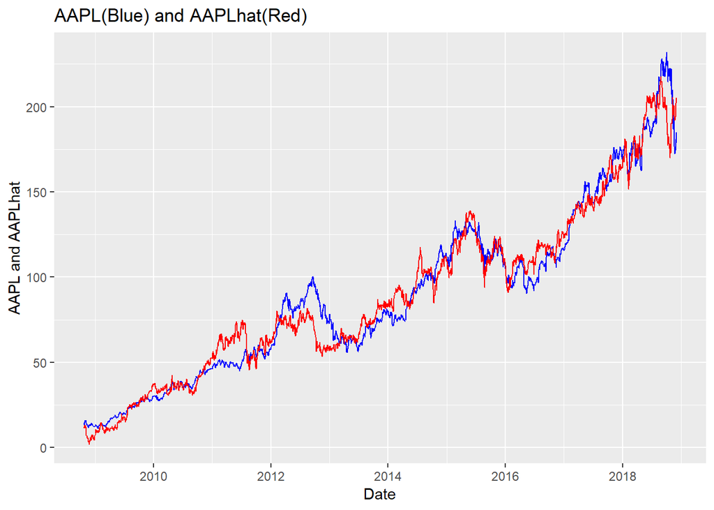

```r
AAPLhat <- predict(lm(AAPL ~ MU + ADI + GLUU + JBL + QCOM + STM + TXN, data=AAPLSTOCK))
AAPLhatdataframe <- data.frame(AAPLhat) #transfer vector to dataframe
AAPLhatdataframe$Date = AAPLSTOCK$Date #Match the date column from Original dataframe to predicted dataframe
ggplot()+
geom_line(data=AAPLSTOCK, aes(x=Date,y=AAPL),color="Blue") +
geom_line(data=AAPLhatdataframe, aes(x=Date, y=AAPLhat), color="Red")+
labs(title="AAPL(Blue) and AAPLhat(Red)", y="AAPL and AAPLhat", x="Date") #Plot a line plot of apple stock and estimated stock price
```

**Hedging Outcome**

We are going to construct a portfolio consists of a long position in Apple stock and a short position of a portfolio of its suppliers stocks assigning weights according to their corresponding regression coefficent. We are going to backtest this strategy’s outcome by simply subtract the predicted value of apple stock from apple actual past stock price. If the hedge is successful, we are able to achieve $0 outcome, and very close to 0 standard deviation.

```r
AAPLhatdataframe$Hedge = AAPLSTOCK$AAPL-AAPLhatdataframe$AAPLhat #Construct a hedge column that is the hedge result
summary(AAPLhatdataframe) #summarize the outcome
```

```
AAPLhat             Date                         Hedge
```

Min. : 2.092 Min. :2008-10-22 00:00:00 Min. :-25.1482  
1st Qu.: 56.651 1st Qu.:2011-05-03 12:00:00 1st Qu.: -6.2209  
Median : 81.883 Median :2013-11-12 00:00:00 Median : -0.3127  
Mean : 89.578 Mean :2013-11-12 17:06:42 Mean : 0.0000  
3rd Qu.:118.884 3rd Qu.:2016-05-24 12:00:00 3rd Qu.: 5.3567  
Max. :217.639 Max. :2018-12-03 00:00:00 Max. : 47.0258

```r
stargazer(AAPLhatdataframe,type="html")
```

| Statistic | N | Mean | St. Dev. | Min | Pctl(25) | Pctl(75) | Max |
| --- | --- | --- | --- | --- | --- | --- | --- |
| AAPLhat | 2,547 | 89.578 | 49.729 | 2.092 | 56.651 | 118.884 | 217.639 |
| Hedge | 2,547 | 0.000 | 10.024 | -25.148 | -6.221 | 5.357 | 47.026 |

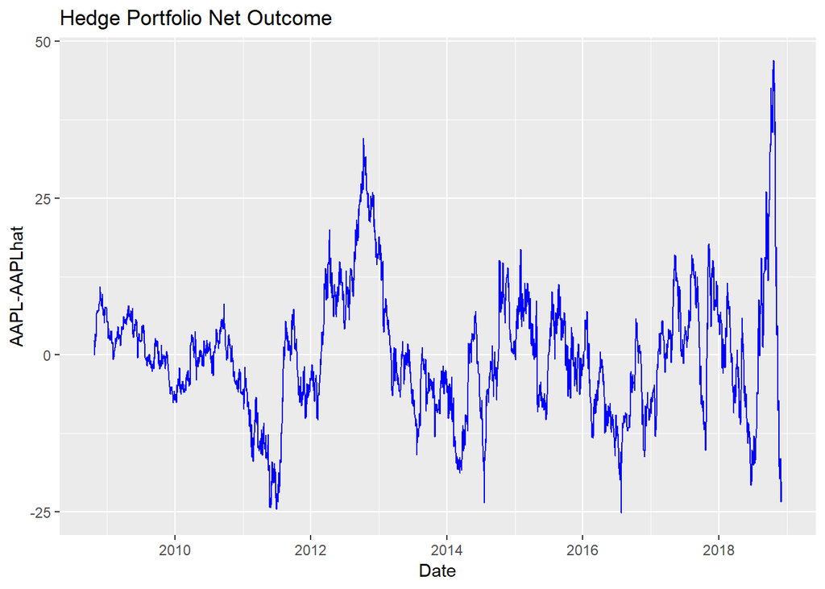

```r
ggplot(AAPLhatdataframe,aes(x=Date,y=Hedge))+
  geom_line(color="Blue")+
  labs(title="Hedge Portfolio Net Outcome", y="AAPL-AAPLhat", x="Date")#draw the line plot of the outcome
```

As we see, the hedge is not perfect, but control the portfolio outcome in the last 10 year to have a mean of 0, and an Standard deviation of 10.

That marks our conclusion of the research. We conclude that all the suppliers’ stocks reasonally explain apple stock price change. However, there are two main limitation: 1.Chance of reverse causation, meaning that it might be Apple’s extraordinary performance that affect all the other suppliers stock. 2.The hedge portfolio consists of all Apple suppliers Stock still cannot fully hedge the price change of Apple. There is tail risk of losing $25 still.